# GR5243 Project1

Name: Chenbohan Zhang UID: cz2738@columbia.edu

# 1. Introduction

# 2. Import Necessary Packages

# 3. Access the Data from Kaggle

## Step 3.1: download the dataset

The entire dataset is posted at Kaggle’s [website](https://www.kaggle.com/datasets/kouroshalizadeh/history-of-philosophy?select=philosophy_data.csv).

## Step 3.2: Assign your data with local path

```r
library("haven")
df <- read_csv("../data/philosophy_data.csv")
```

Our df data set has 360808 respondents and 11 variables.

Here’s the head of our data set.

```r
head(df)
```

```
## # A tibble: 6 × 11
##   title    author school sente…¹ sente…² origi…³ corpu…⁴ sente…⁵ sente…⁶ token…⁷
##   <chr>    <chr>  <chr>  <chr>   <chr>     <dbl>   <dbl>   <dbl> <chr>   <chr>
## 1 Plato -… Plato  plato  What's… What's…    -350    1997     125 what's… ['what…
## 2 Plato -… Plato  plato  Surely… Surely…    -350    1997      69 surely… ['sure…
## 3 Plato -… Plato  plato  The At… The At…    -350    1997      74 the at… ['the'…
## 4 Plato -… Plato  plato  What i… What i…    -350    1997      21 what i… ['what…
## 5 Plato -… Plato  plato  Someon… Someon…    -350    1997     101 someon… ['some…
## 6 Plato -… Plato  plato  But so… But so…    -350    1997      34 but so… ['but'…
## # … with 1 more variable: lemmatized_str <chr>, and abbreviated variable names
## #   ¹sentence_spacy, ²sentence_str, ³original_publication_date,
## #   ⁴corpus_edition_date, ⁵sentence_length, ⁶sentence_lowered, ⁷tokenized_txt
```

```r
col_name <- names(df)
print(col_name)
```

```
##  [1] "title"                     "author"
##  [3] "school"                    "sentence_spacy"
##  [5] "sentence_str"              "original_publication_date"
##  [7] "corpus_edition_date"       "sentence_length"
##  [9] "sentence_lowered"          "tokenized_txt"
## [11] "lemmatized_str"
```

The columns are title, author, school, sentence_spacy, sentence_str, original_publication_date, corpus_edition_date, sentence_length, sentence_lowered, tokenized_txt, lemmatized_str.

## Step 3.3: Cleaning Data Set

Kaggle has shown that no column are mismatched nor missing. The data set could be previously cleaned. So we can treat the original data set as a cleaned up version.

[figure not shown]

# Step 4: Analysis

## Step 4.1: What are the most popular school among all the time?

The intuitive is to find out the total amount of paper writtened by each school under each period.

### Step 4.1.1: Getting Necessary Columns and Process the Data

In order to answer the question, we should get the “title”, “school”, and “original_publication_date” columns.

```r
df1 <- df %>% dplyr::select(title,school,original_publication_date)
head(df1)
```

```
## # A tibble: 6 × 3
##   title                  school original_publication_date
##   <chr>                  <chr>                      <dbl>
## 1 Plato - Complete Works plato                       -350
## 2 Plato - Complete Works plato                       -350
## 3 Plato - Complete Works plato                       -350
## 4 Plato - Complete Works plato                       -350
## 5 Plato - Complete Works plato                       -350
## 6 Plato - Complete Works plato                       -350
```

After extracting the necessary columns, we should use group by to sum up all the papers.

```r
df1_sum <- df1 %>% group_by(school,original_publication_date) %>% summarize(total_paper=n(),.groups = 'drop')
```

Now, we tried to plot a multi-line graph based on school and year.

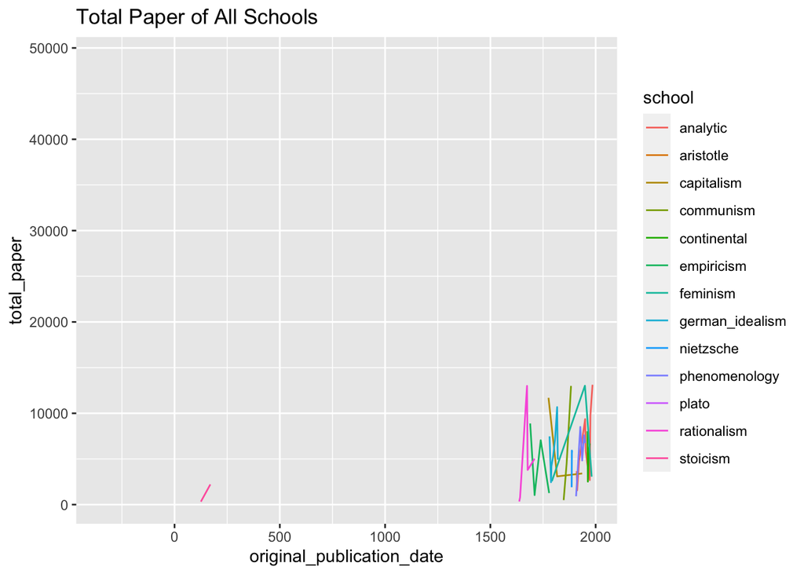

```r
ggplot(data = df1_sum, aes(x=original_publication_date, y=total_paper,colour=school)) + geom_line() + labs(title="Total Paper of All Schools")
```

Hold on, this doesn’t look right!

### Step 4.1.2: Slicing Up Data Set and Shift Focus

To dig further into our data set, we could only keep the data from 1500-2000 and see which school was famous that time.

```r
df1_sub =df1_sum[df1_sum$original_publication_date>=1500 & df1_sum$original_publication_date<=2000, ]
```

After subsetting, there are only few schools left. These are analytic, capitalism, communism, continental, empiricism, feminism, german_idealism, nietzsche, phenomenology, rationalism

We then plot a graph based on the above subsetted data set.

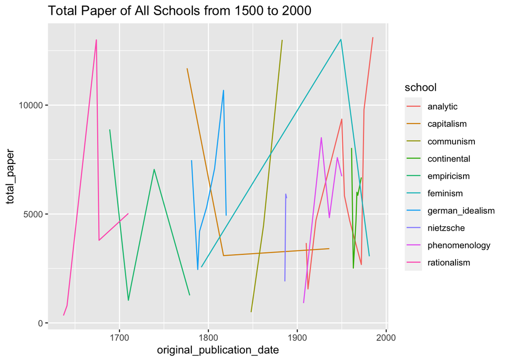

```r
ggplot(data = df1_sub, aes(x=original_publication_date, y=total_paper,colour=school)) + geom_line() + labs(title="Total Paper of All Schools from 1500 to 2000")
```

## Step 4.2: What’s the difference among all the famous schools of all the time?

### Step 4.2.1: Getting Necessary Columns

In order to answer question 4.2, we need column “school”, original_publication_date”, “sentence_length”, “tokenized_txt”.

```r
df2 <- df %>% dplyr::select(school,original_publication_date,sentence_length, tokenized_txt)
df2_sub <- df2[df2$school %in% c('plato','rationalism','analytic'),]
head(df2_sub)
```

```
## # A tibble: 6 × 4
##   school original_publication_date sentence_length tokenized_txt
##   <chr>                      <dbl>           <dbl> <chr>
## 1 plato                       -350             125 ['what', 'new', 'socrates', …
## 2 plato                       -350              69 ['surely', 'you', 'are', 'no…
## 3 plato                       -350              74 ['the', 'athenians', 'do', '…
## 4 plato                       -350              21 ['what', 'is', 'this', 'you'…
## 5 plato                       -350             101 ['someone', 'must', 'have', …
## 6 plato                       -350              34 ['but', 'someone', 'else', '…
```

### Step 4.2.2: Analysis on Sentence Length

Let’s first look into the average length of one piece of work in each school, so that we might see the potential different style of writing among those schools.

```r
df2_avg <- df2_sub %>% group_by(school) %>% summarize(avg_length=mean(sentence_length),.groups = 'drop')
```

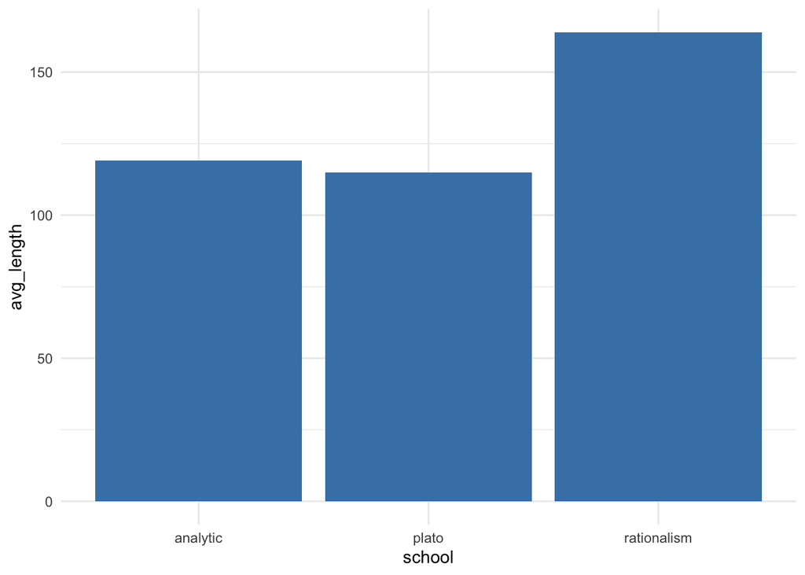

```r
p<-ggplot(data=df2_avg, aes(x=school, y=avg_length)) +
  geom_bar(stat="identity", fill="steelblue")+
  theme_minimal()

p
```

In the graph, we can see that there is no such huge difference between school analytic and plato, but in rationalism, there are 50 words more in every sentence on average. Rationalism is defined to regard reason as the chief source and test of knowledge. Rationalist believes the reality follows a intrinsically logical way. Thus, a relatively long structure of sentence could be due to their fully logical reasoning.